# Deliverable 4

2026-11-04

# Deliverable 4

## Changes Since Deliverable 3

I have created the new variables remote_work

| Variable Name | Represents | Type |
| --- | --- | --- |
| work_year | Year the salary record was collected | Numerical |
| experience_level | Experience code (EN, MI, SE, EX) | Categorical |
| employment_type | Employment type code (FT, PT, CT, FL) | Categorical |
| job_title | Job title of employee | Categorical |
| salary | Salary (original currency) | Numerical |
| salary_currency | Currency used for salary | Categorical |
| salary_in_usd | Salary converted to U.S. dollars | Numerical |
| employee_residence | Employees country of residence | Categorical |
| remote_ratio | Percentage of remote work (0, 50, 100) | Numerical |
| company_location | Location of the company | Categorical |
| company_size | Size of company (S, M, L) | Categorical |
| experience_level_label | Full experience description | Categorical |
| employment_type_label | Full employment description | Categorical |
| work_mode | On-Site, Hybrid, Remote | Categorical |
| salary_outlier_flag | Indicates if salary is an outlier | Categorical |
| role_family | Grouped job category | Categorical |
| isco_group_hint | Occupational classification | Categorical |
| remote_work | Remote work category derived from the ratio | Categorical |

I also created summary datasets (salary_trends, salary_exp_level, salary_by_company_exp, and top_jobs) to support data visualizations and analysis.

I also create six new graphics and modified my “Work Mode Distribution” bar chart by making it a box plot so it could covey the information better. Then I also updated and improved my explanations from the graphics I brought over from deliverable 3.

## Data visualizations

```r
library(ggplot2)
library(dplyr)
jobs <- read.csv("ai_jobs_salaries_clean.csv")
```

### Histogram of the Salaries

Distribution of one variable

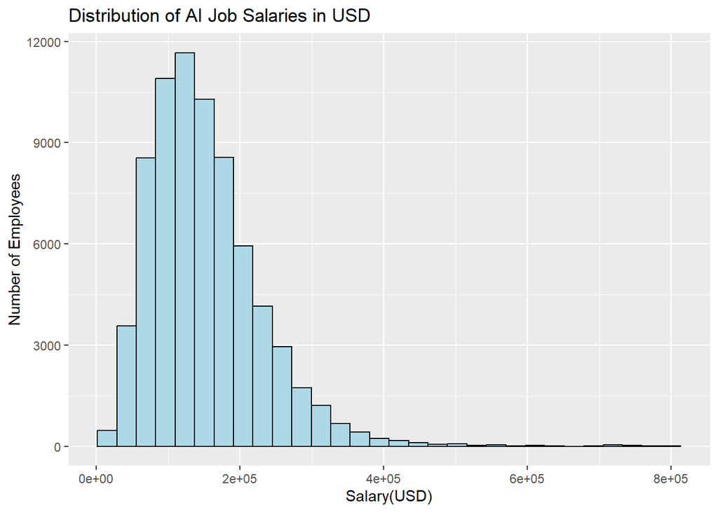

```r
ggplot(jobs, aes(x = salary_in_usd)) +
  geom_histogram(fill = "lightblue", color = "black") +
    labs(
      title = "Distribution of AI Job Salaries in USD",
      x = "Salary(USD)",
      y = "Number of Employees"
    )
```

This figure shows the distribution of salaries in the AI jobs using the variable *salary_in_usd*. Most of these salaries are concentrated within the lower and middle ranges, while a smaller number of jobs receive considerably higher salaries. This distribution is positively skewed, so that means the salary ranges extends further towards the high-income values. This suggests that while many AI professional could earn competitive salaries, only a small percentage occupy the highest paying positions. Which also suggested that advanced leadership and specialized AI roles have a significantly higher compensation. The next thing I would next examine would be whether experience level, job title, or company size contributes most to these higher earnings.

### Bar Chart of Amount of Jobs for Each Experience Level

Comparison across groups

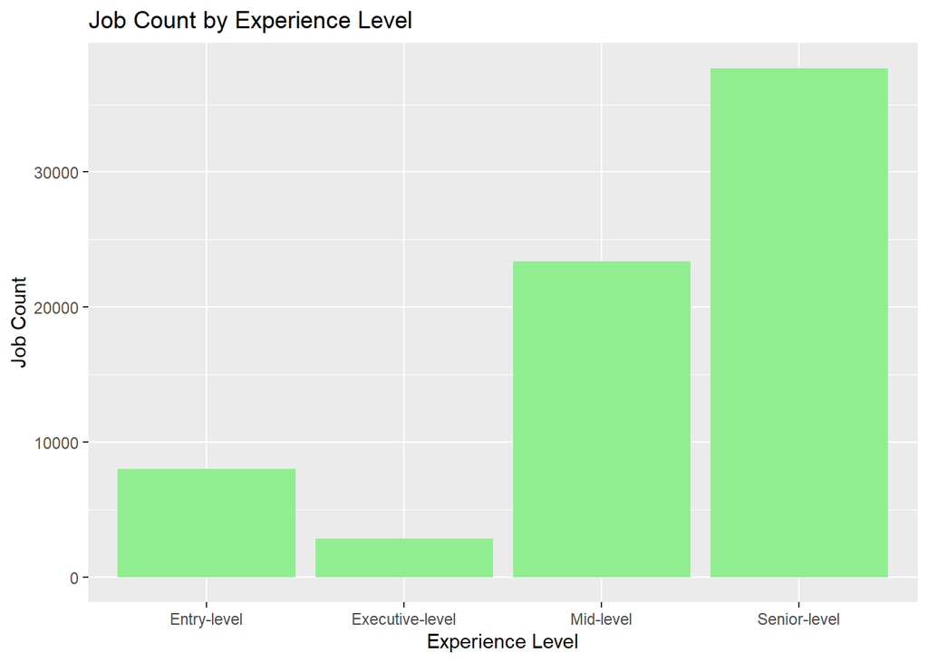

```r
ggplot(jobs, aes(x = experience_level_label)) +
  geom_bar(fill = "lightgreen") +
    labs(
      title = "Job Count by Experience Level",
      x = "Experience Level",
      y = "Job Count"
    )
```

### Boxplot of Salary by Experience Level

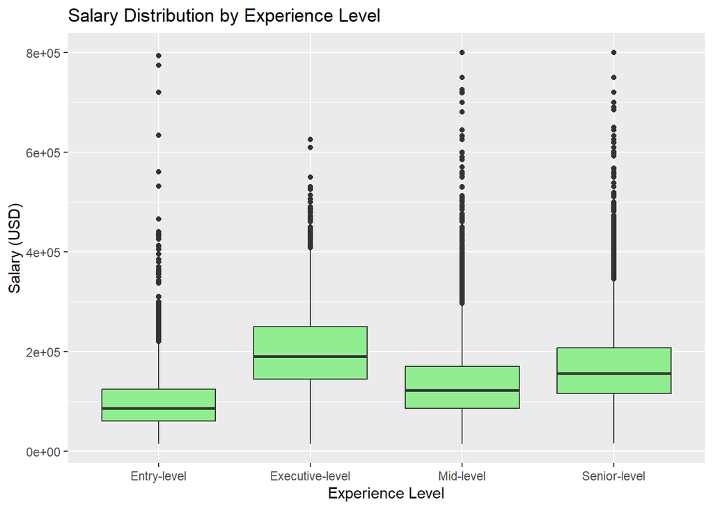

```r
ggplot(jobs, aes(x = experience_level_label, y = salary_in_usd)) +
  geom_boxplot(fill = "lightgreen") +
    labs(
      title = "Salary Distribution by Experience Level",
      x = "Experience Level",
      y = "Salary (USD)"
    )
```

This figure compares salary distributions across experience levels using the variables *experience_level_label* and *salary_in_usd*. The boxplot displays the median salary, spread of salaries, and potential outliers for each experience level. The chart shows that salaries generally increase as experience levels. It appears that the entry level salaries is relatively concentrated, while mid and senior level salaries have a wider spread, and executive level salaries have the widest spread. Which tells us that employees with the same experience level and vary, especially at higher levels.

### Boxplot of Salary Compared to Working Remote

Relationship between two numerical values

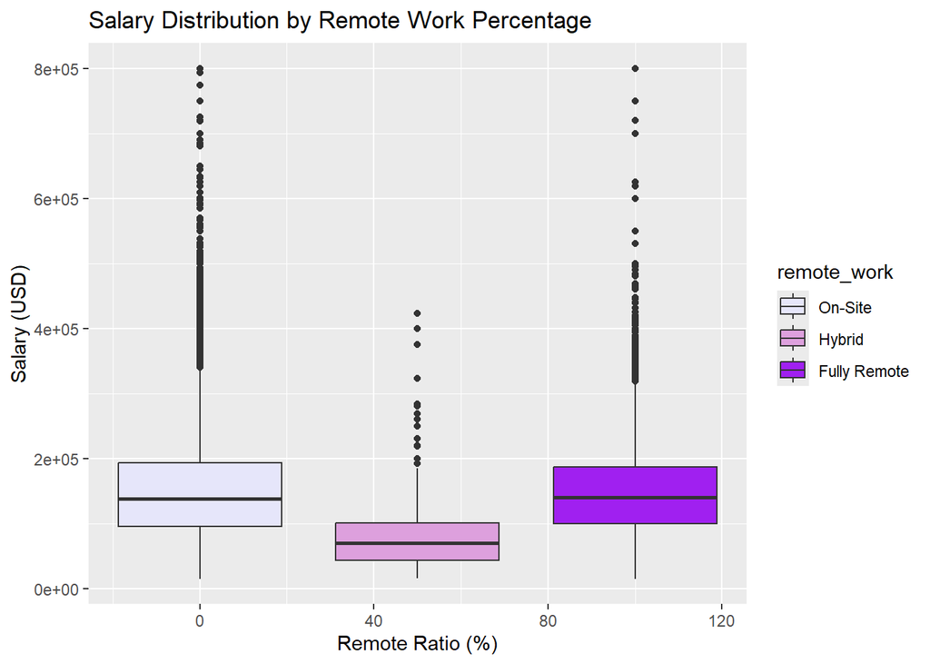

```r
jobs <- jobs %>%
  mutate(remote_work = factor(remote_ratio,
                levels = c(0, 50, 100),
                labels = c("On-Site", "Hybrid", "Fully Remote")
              )
         )

ggplot(jobs, aes(x = remote_ratio, y = salary_in_usd, fill = remote_work)) +
  geom_boxplot() +
  scale_fill_manual(values = c("lavender", "plum", "purple")) +
    labs (
      title = "Salary Distribution by Remote Work Percentage",
      x = "Remote Ratio (%)",
      y = "Salary (USD)"
    )
```

This figure compare the salary distribution across different work arrangements using the variables *remote_work* and *salary_in_usd*. This box plot shows the median salary, the spread of salaries, and potential outliers for each type of position. This figure suggests that Fully Remote and On-Site generally have higher salary distributions than the Hybrid position. All three contain a wide range of salaries, having numerous high-salary outliers, especially Fully Remote and On-Site. This indicates that employees within the same work arrangement can earn substantially different amounts. Because of this variability this suggests that factors outside of work arrangement influence compensation. As from these results, work status alone does not appear to be the strongest predictor of salary. Other variables, such as experience level, company size, and job role could influence earnings.

### Salary Trend Overtime

Trend over time

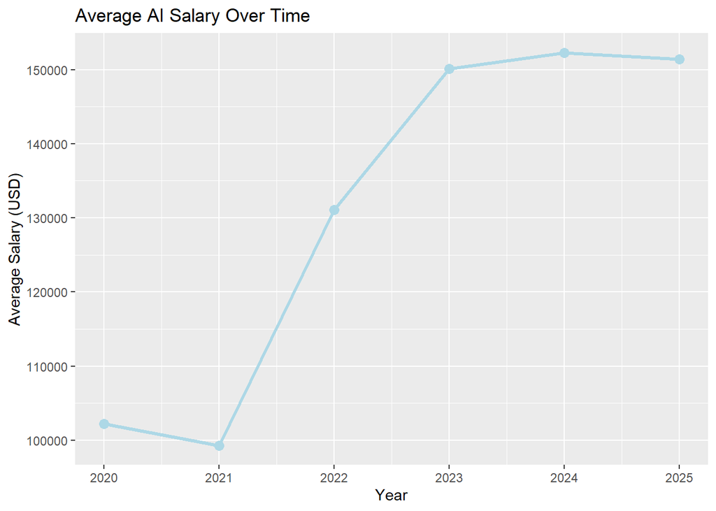

```r
salary_trend <- jobs %>%
  group_by(work_year) %>%
  summarise(avg_salary = mean(salary_in_usd))

ggplot(salary_trend, aes(x = work_year, y = avg_salary)) +
  geom_line(color = "lightblue", linewidth = 1.2) +
  geom_point(color = "lightblue", size = 3) +
    labs(
      title = "Average AI Salary Over Time",
      x = "Year",
      y = "Average Salary (USD)"
    )
```

This figure displays the average salary over time using the variables *work_year* and *salary_in_usd*. The chart illustrates how average compensation levels have changed across the years represented in the data set (2020-2025). It appears that the average salary decreased slightly from 2020 to 2021, followed by a substantial increase from 2021 through 2024. The average salaries then remained relatively stable between 2024 and 2025.This trend in average salary suggests that AI-related occupations experienced strong salary growth within the period represented within the data set. An explanation for this increased demand could reflect growth in demand for AI professionals, changing market conditions, or evolving industry priorities. The salaries increasing suggest that AI-related skills have become increasing valuable within the labor market. Additional analysis could investigate whether salary growth occurred equally across experience levels or whether higher- level positions benefited more strongly from the increase in demand.

### Salary Growth by Experience Level

```r
salary_exp_level <- jobs %>%
  group_by(work_year, experience_level_label) %>%
  summarise(avg_salary = mean(salary_in_usd))
```

[output not shown]

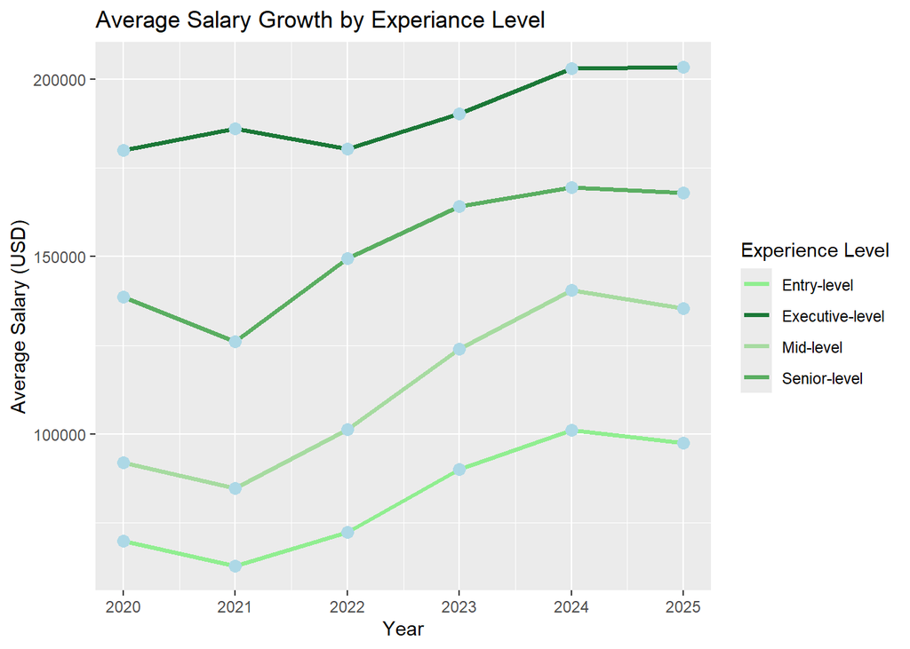

```r
ggplot(salary_exp_level, aes(x = work_year, y = avg_salary, color = experience_level_label)) +
  geom_line(linewidth = 1.2) +
  geom_point(color = "lightblue", size = 3) +
  scale_color_manual(values = c(
    "Entry-level" = "lightgreen",
    "Mid-level" = "#a6dba0",
    "Senior-level" = "#5aae61",
    "Executive-level" = "#1b7837"
  )) +
    labs(
      title = "Average Salary Growth by Experiance Level",
      x = "Year",
      y = "Average Salary (USD)",
      color = "Experience Level"
    )
```

This figure displays average salary trends over time for each experience level using the variables *work_year*, *salary_in_usd*, and *experience_level_label*. The chart compares how the salaries change between 2020 through 2025 for entry-level, mid-level, senior-level, and executive-level employees. This graph shows that most experience levels experienced a small decline in 2021 before the salaries increased substantially through 2024. This suggests that salary growth occurred across all experience levels, but the higher-level positions continues to receive the greatest compensation. The experience levels not overlapping at all suggests that experience plays a significant role in determining salary within AI-related careers. A useful next step would be to investigate other factors such as job title and company size could contribute to these differences and weather certain industries experienced strong salary growth.

### Scatterplot Comparing Average Salary Between Count of Job Records

Relationship between two numerical values

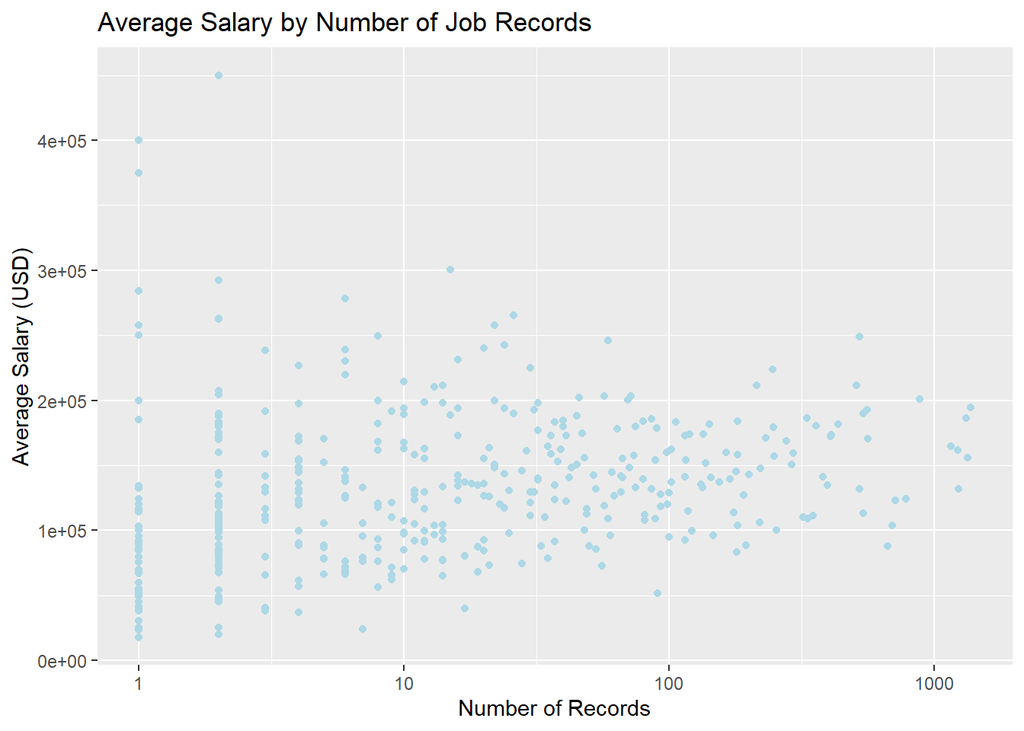

```r
salary_job <- jobs %>%
  group_by(job_title) %>%
  summarise(avg_salary = mean(salary_in_usd), count = n())

salary_job_no_outliers <- salary_job %>%
  filter(count < 2000)

ggplot(salary_job_no_outliers, aes(x = count, y = avg_salary)) +
  geom_point(color = "lightblue") +
  scale_x_log10() +
    labs(
      title = "Average Salary by Number of Job Records",
      x = "Number of Records",
      y = "Average Salary (USD)"
    )
```

This figure shows the relationship between the number of job records for a given job title and the average salary associated with that job title. The variables used are *count* and *avg_salary* calculated for each job title. This scatter plot shows a large variable in average salary across the job title regardless of how frequently those positions appear in the data-set. These results suggest that the popularity/frequency of a job title is not strongly related to average compensation. So the next useful step would be to identify which job titles are associated with the highest salaries

### Boxplot of Salary Distribution by Company Size

Relationship between two numerical values

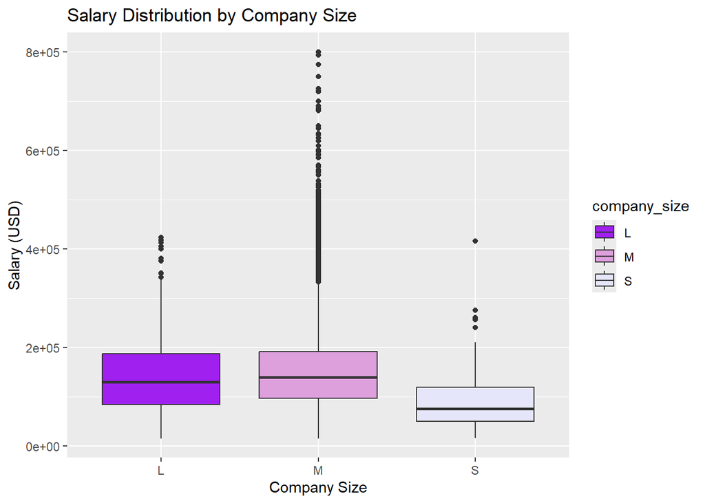

```r
ggplot(jobs, aes(x = company_size, y = salary_in_usd, fill = company_size)) +
  geom_boxplot() +
  scale_fill_manual (values = c(
    "S" = "lavender",
    "M" = "plum",
    "L" = "purple"
  )) +
    labs(
      title = "Salary Distribution by Company Size",
      x = "Company Size",
      y = "Salary (USD)"
    )
```

This figure compares salary distributions across different company sizes using the variable *company_size* and *salary_in_usd*. The boxplots show the median salary, salary spread, and the outliers for the small, medium, and large companies. This chart suggests employees working for medium and large companies generally tend to earn higher salaries than the employees at smaller organizations. Although there is an overlap between the groups, medium company’s appear to have the widest range of salaries. They have the widest range and the largest number of high-salary outliers so there is substantial variation in compensation. This could be explained by the larger companies having a greater financial resources and a higher demand for the specialized AI talent. A useful next step would be to examine whether employees with similar experience levels receive different compensation depending the company size.

### Average Salary by Company Size and Experience Level

```r
salary_by_company_exp <- jobs %>%
  group_by(company_size, experience_level_label) %>%
  summarise(avg_salary = mean(salary_in_usd))
```

[output not shown]

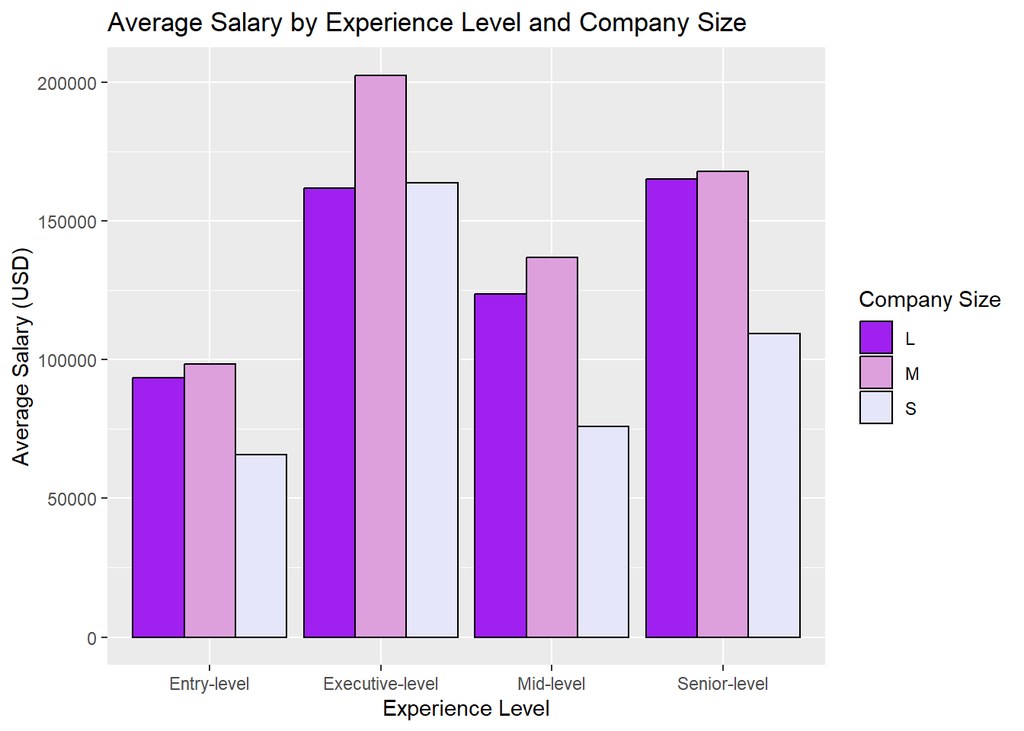

```r
ggplot(salary_by_company_exp, aes(x = experience_level_label, y = avg_salary, fill = company_size)) +
  geom_col(position = "dodge", color = "black") +
  scale_fill_manual(values = c(
    "S" = "lavender",
    "M" = "plum",
    "L" = "purple"
  )) +
    labs(
      title = "Average Salary by Experience Level and Company Size",
      x = "Experience Level",
      y = "Average Salary (USD)",
      fill = "Company Size"
    )
```

### Top 10 Highest Paying Job Titles

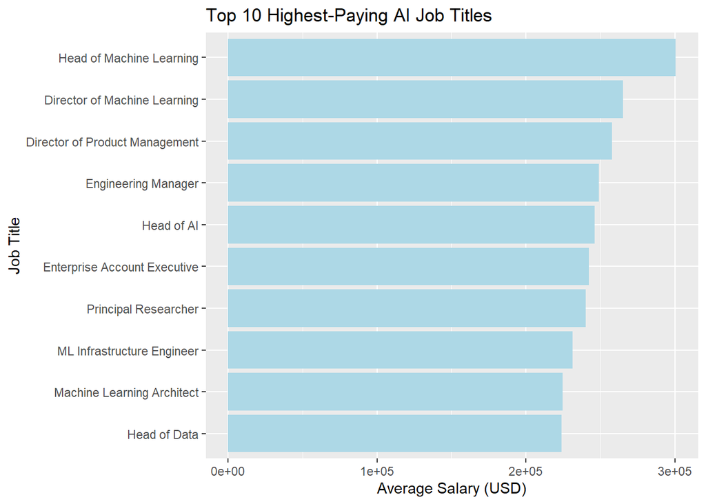

```r
top_jobs <- jobs %>%
  group_by(job_title) %>%
  summarise(avg_salary = mean(salary_in_usd), count = n()) %>%
  filter(count >= 10) %>%
  arrange(desc(avg_salary)) %>%
  slice_head(n = 10)

ggplot(top_jobs, aes(x = reorder(job_title, avg_salary), y = avg_salary)) +
  geom_col(fill = "lightblue") +
  coord_flip() +
    labs(
      title = "Top 10 Highest-Paying AI Job Titles",
      x = "Job Title",
      y = "Average Salary (USD)"
    )
```

This figure displays the ten job titles with the highest average salary using the variables *job_title* and *salary_in_usd*. Only job titles with at least ten records observations were includes to avoid the results be influenced from very small sample sizes. This chart suggests that specialized and leadership-focused AI positions have the highest salary in the industry. This finding supports that technical expertise makes you an high value employee. An explanation for this is that these positions require extensive experience, specialized knowledge, and strategic decision-making. One of the next things I will examine is whether remote, hybrid and in person positions show any salary differences after accounting for the experience levels.

## Overall Take

Throughout this analysis I have learned that experience level appears to be of the strongest factors influencing salary within AI-related careers. The visualizations consistently showed that the average salaries in AI occupations have generally increased over time, which suggests that the demand for AI-related skills has grown between 2020 and 2025. While remote work status showed some differences within the salary distributions, the experience level and company size appear to have a stronger relationship with compensation.

One finding that surprised me was that the medium-sized companies offered salaries that were comparable to, or higher than those provided by the large companies. I had expected the large organizations to consistently pay the highest salaries due to them having greater resources. This analysis suggests that there is a more complex relationship between the company size and salary, than originally expected. Another interesting finding was the large variation in the salaries among employees with the same experience level, particularly among the higher levels. This is an indication of there being additional factors beyond experience, that may have a significant impact on earnings.

There are still some other questions that I would like to further explore. Like for example whether geographical location has a significant impact on AI-related salaries as well as how compensation differs between countries. I would also like to examine whether remote, hybrid and in person positions show any salary differences after accounting for the experience levels. I also think it would be good to analyze how company size and and experience level interact to influence compensation and determine which combination would lead to the highest earnings. For my final draft, I plan to preform some additional analyses on these topics mentioned above so that I can gain a deeper understanding of the salary differences within AI careers. I also need to refine my visualizations and explanation so I can provide a clearly communicated data supported by my findings. So that there is a complete picture for what influences salaries in AI-related occupations.